# Rendimiento y Riesgo

Luis Jiménez

2025-02-11

## 1 Explicacion

Ya sabemos que los cambios en el precio tienen un comportamiento dado por la EDE:

### 1.1 Ecuación

$$dS = S\mu dt + S\sigma dW$$

Los valores de los parámetros $\mu, \sigma$ dependen del tiempo, por lo cual, debemos definir si serán diarios, serán anualizados o que características vamos a considerar.

```r
library(quantmod)
library(lubridate)
ticker <- "GFNORTEO.MX"
datos <- new.env()
getSymbols(ticker, from="2000-01-02", to=today(), env=datos)
```

```
## [1] "GFNORTEO.MX"
```

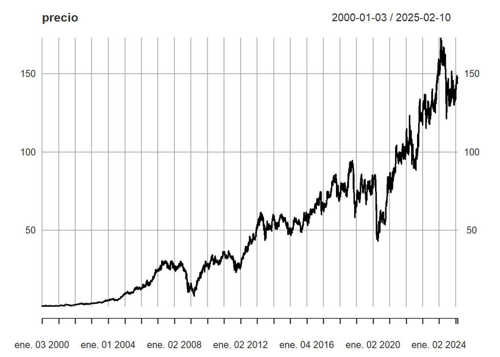

```r
precio <- datos[[ticker]][,6]
plot(precio)
```

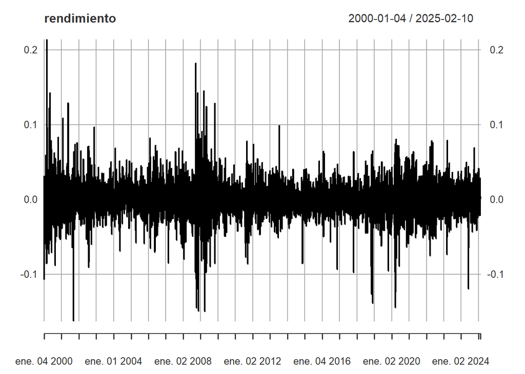

```r
rendimiento <- na.omit(diff(log(precio)))
plot(rendimiento)
```

Decíamos que los parámetros dependen del tiempo. Primero consideraremos los datos históricos, es decir todos los datos que existen:

```r
mu_di_his <- mean(rendimiento)
sigma_di_hist <- sd(rendimiento)
mu_di_his
```

```
## [1] 0.0006874502
```

```r
sigma_di_hist
```

```
## [1] 0.02301177
```

Estos parámetros podemos anualizarlos para que tengan una mejor interprestación:

```r
mu_anual_hist <- mu_di_his * 252
sigma_anual_hist <- sigma_di_hist * 252^(1/2)
mu_anual_hist
```

```
## [1] 0.1732375
```

```r
sigma_anual_hist
```

```
## [1] 0.3653006
```

Vamos a clauclar estos mismos parámetros para cada uno de los años de información que tenemos

```r
library(dplyr)
names(rendimiento) <- "rend"
tabla <- rendimiento |>
  as_tibble() |>
  mutate(year=year(rendimiento)) |>
  group_by(year) |>
  summarise("Ren_Diario"=mean(rend),
            "Vol_Diaria"=sd(rend),
            "Ren_Anual"=mean(rend)*252,
            "Vol_Anual"=sd(rend)*sqrt(252))

tabla
```

```
## # A tibble: 26 × 5
##     year Ren_Diario Vol_Diaria Ren_Anual Vol_Anual
##    <dbl>      <dbl>      <dbl>     <dbl>     <dbl>
##  1  2000  -0.000325     0.0356   -0.0818     0.564
##  2  2001   0.00147      0.0264    0.371      0.419
##  3  2002   0.00128      0.0228    0.323      0.362
##  4  2003   0.00170      0.0159    0.430      0.253
##  5  2004   0.00231      0.0167    0.583      0.266
##  6  2005   0.000975     0.0160    0.246      0.254
##  7  2006   0.00250      0.0225    0.630      0.357
##  8  2007   0.000293     0.0215    0.0739     0.342
##  9  2008  -0.00228      0.0382   -0.574      0.606
## 10  2009   0.00261      0.0388    0.658      0.616
## # ℹ 16 more rows
```

Hasta ahora hmos ocnsiderado que los rendimientos tienen el supuesto de normalidad (esto sucede porque los rendimientos se explica por un proceso estocastico, que está determinado por un $\epsilon$ que tiene media cero y varianza 1)

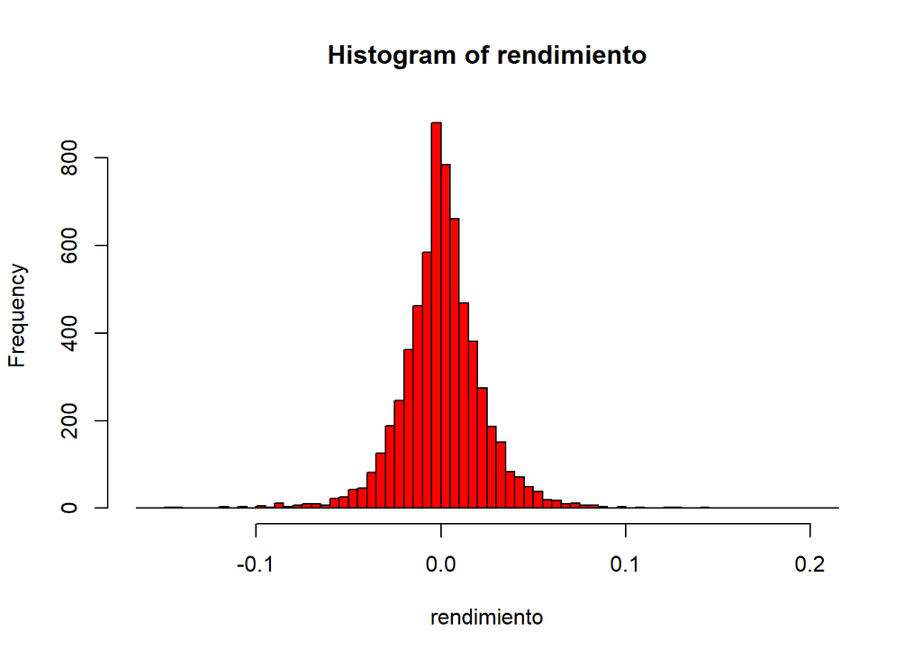

```r
hist(rendimiento, n=100, col="red")
```

Vamos a efectuar un prueba formal de NORMALIDAD. Una pruebe formal nos indica si estrictamente la variable sigue o no el comportamiento deseado. En este caso, la prueba que usaremos se llama Jarque-Bera y consiste en una prueba de hipótesis, con una nula y otra alternativa y usamos el valore del P-Value para decidir.

(NORA: PARA MI PROTECTO TERCERA ENTREGA SERÁ NECESARIO QUE HAGA UNA PRUEBA DE NORMALIDAD, ENTONCES DEBO INVERSTIGAR QUE ES LA PRUEBA, QUE CARACTERÍSTICA TIENE Y TUDA LA INFORMACIÓN RELEVANTE).

- $H_0$: Hay normalidad en los datos.
- $H_a$: No hay normalidad.

```r
library(moments)
jarque.test(as.numeric(rendimiento))
```

```
##
##  Jarque-Bera Normality Test
##
## data:  as.numeric(rendimiento)
## JB = 11885, p-value < 2.2e-16
## alternative hypothesis: greater
```

El P-Value es la probabilidad de cometer el error de tipo I.

- Error de tipo I (rechazar $H_0$ cuando es verdadera).

Interpretación: Prácticamente hay 0% de probabilidades de rechazar $H_0$ cuando es verdadera, por lo que aceptamos la hipótesis alternativa.

Conclusión: los datos del rendimiento no son normalos dado que tienen leptocurtosis, es decir un excesos de curtosis respecto a lo que es normal.

La prueba que acabamos de hacer compara la distribución de los datos que le damos con los de una normal. La normal tiene dos características, sesgo cero y custorsis 3.

```r
skewness(rendimiento)
```

```
##        rend
## -0.02173283
```

```r
kurtosis(rendimiento)
```

```
##    rend
## 9.69003
```

```r
jarque.test(as.numeric(precio))
```

```
##
##  Jarque-Bera Normality Test
##
## data:  as.numeric(precio)
## JB = 730.43, p-value < 2.2e-16
## alternative hypothesis: greater
```

Ahora hagamos la prueba de rendimiento diario promedio igual a cer.

- $H_0$: La media del rendimiento diario es cero.
- $H_a$: NoLa media del rendimiento diario es diferente de cero.

```r
t.test(as.numeric(rendimiento), mu=0, alternative="two.sided")
```

```
##
##  One Sample t-test
##
## data:  as.numeric(rendimiento)
## t = 2.3849, df = 6372, p-value = 0.01711
## alternative hypothesis: true mean is not equal to 0
## 95 percent confidence interval:
##  0.0001223718 0.0012525286
## sample estimates:
##    mean of x
## 0.0006874502
```